```r
# dtab(result, perc = TRUE, dec = 2) %>% render()
```

**Eat Frequency Distribution**

```r
visualize(
  project_data,
  xvar = "Q6_Frequency",
  type = "dist",
  fill = "Q6_Frequency",
  labs = list(
    title = "Chinese Food Eating Frequency Distribution",
    caption = "1 = Daily\n2 = A few times a week\n3 = A few times a month\n4 = Never\n",
    x = "Chinese Food Eating",
    y = "Frequency"
  ),
  custom = FALSE
)
```

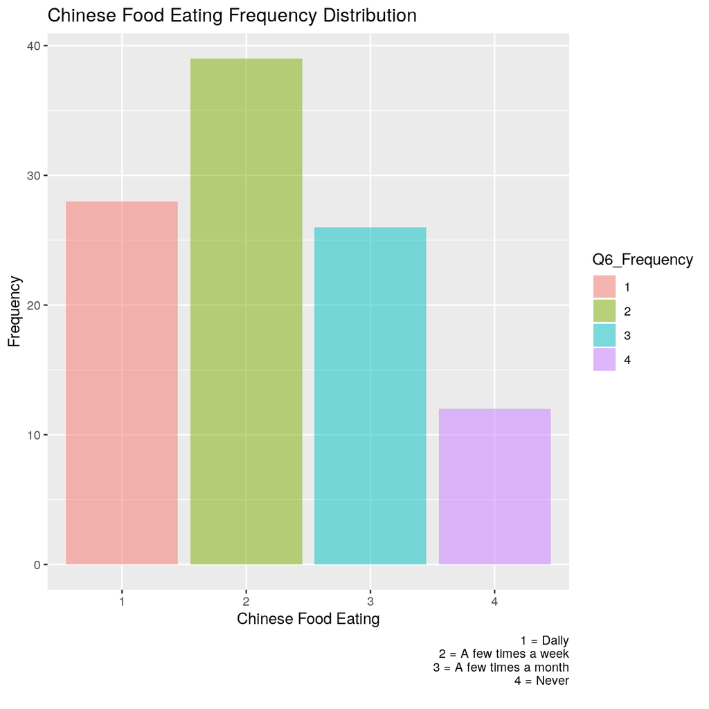

```r
result <- pivotr(
  project_data,
  cvars = "Q6_Frequency",
  normalize = "total",
  nr = Inf
)
summary(result, perc = TRUE, dec = 2)
```

```
Pivot table
Data        : project_data
Categorical : Q6_Frequency
Normalize by: total

 Q6_Frequency   n_obs
            1  26.67%
            2  37.14%
            3  24.76%
            4  11.43%
        Total 100.00%
```

```r
# dtab(result, perc = TRUE, dec = 2) %>% render()
```

> From the data, we can find that around 11.43% of the sample size (only 12 people) in our data never eat Chinese food and over 60% of the sample size eat Chinese food at least a few times a month. This indicates that the size of potential customers for Chinese food is large.

**Spicy Preference**

```r
visualize(
  project_data,
  xvar = "Q9_Spicy",
  type = "dist",
  fill = "Q9_Spicy",
  labs = list(
    title = "Spicy Preference Distribution",
    caption = "1 = Like a great deal\n2 = Like somewhat\n3 = Neither like or dislike\n4 = Dislike somewhat\n5 = Dislike a great deal\n",
    x = "Spicy Preference",
    y = "Counts"
  ),
  custom = FALSE
)
```

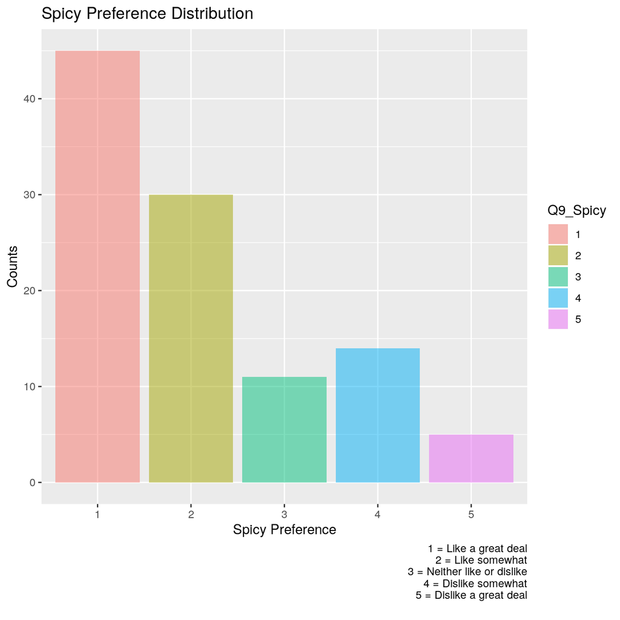

```r
result <- pivotr(
  project_data,
  cvars = "Q9_Spicy",
  normalize = "total",
  nr = Inf
)
summary(result, perc = TRUE, dec = 2)
```

```
Pivot table
Data        : project_data
Categorical : Q9_Spicy
Normalize by: total

 Q9_Spicy   n_obs
        1  42.86%
        2  28.57%
        3  10.48%
        4  13.33%
        5   4.76%
    Total 100.00%
```

```r
# dtab(result, perc = TRUE, dec = 2) %>% render()
```

> We can find that 42.86% of our sample size like spciy food, which also indicate that there can be a great number of potential customers since one characteristic of Taste of Hunan is that it serve tasty spicy food.

### Part B. Location

**Frequency & Location Distribution**

> To determine whether the owner of Taste of Hunan should open a new branch on campus, we also summarize the frequency and locations that students and faculty eat on campus. The distributions are shown as below:

```r
visualize(
  project_data,
  xvar = "Q10_Meals",
  type = "dist",
  fill = "Q10_Meals",
  labs = list(
    title = "Meals Frequency On Campus",
    subtitle = "Every Week",
    caption = "1 = Less than 5 meals\n2 = 5-10 meals\n3 = More than 10 meals\n",
    x = "Meals",
    y = "Frequency"
  ),
  custom = FALSE
)
```

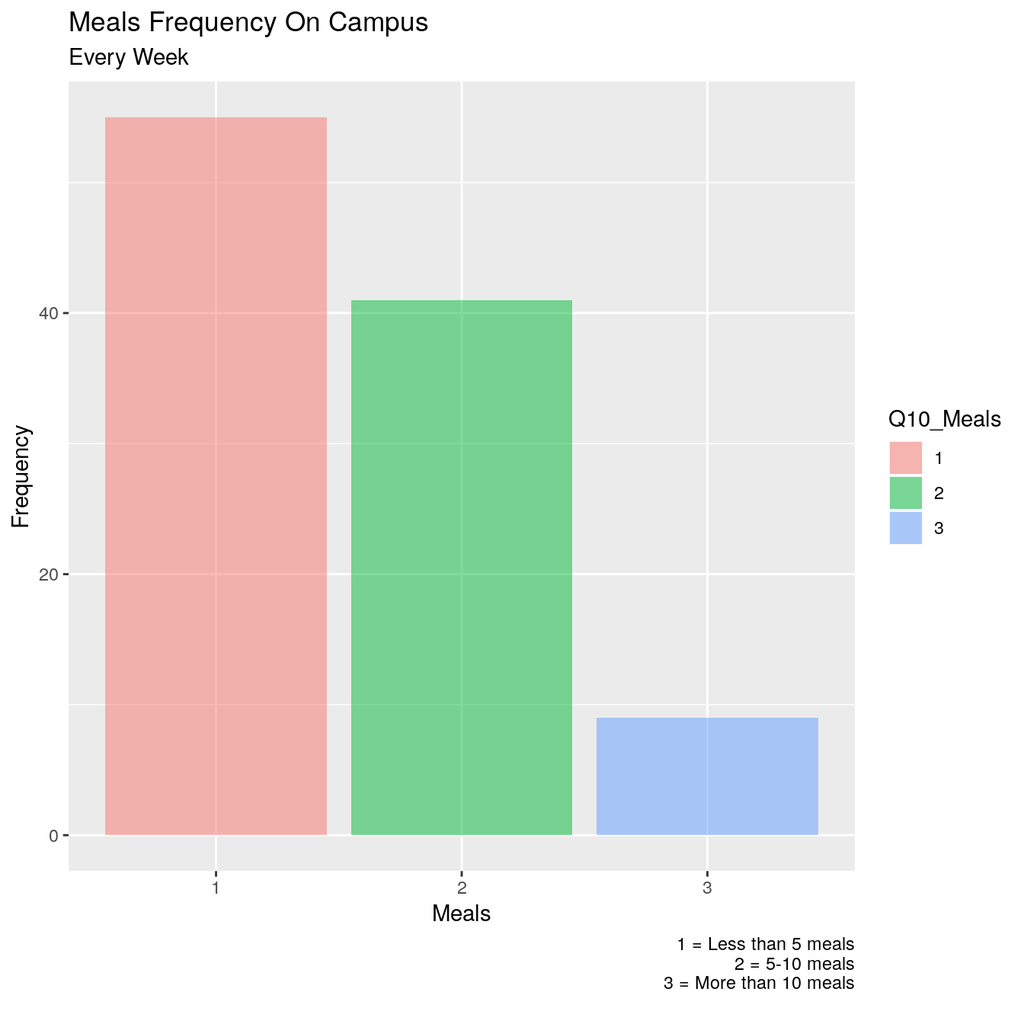

```r
result <- pivotr(
  project_data,
  cvars = "Q10_Meals",
  normalize = "total",
  nr = Inf
)
summary(result, perc = TRUE, dec = 2)
```

```
Pivot table
Data        : project_data
Categorical : Q10_Meals
Normalize by: total

 Q10_Meals   n_obs
         1  52.38%
         2  39.05%
         3   8.57%
     Total 100.00%
```

```r
# dtab(result, perc = TRUE, dec = 2) %>% render()
```

> We can find that over half of our sample size eat less than 5 meals on campus.

```r
visualize(
  project_data,
  xvar = "Q11_PlaceToEat",
  type = "dist",
  fill = "Q11_PlaceToEat",
  labs = list(
    title = "Eating Location On Campus",
    subtitle = "Every Week",
    caption = "1 = Price Center\n2 = College restaurants\n3 = Markets\n4 = Other places on campus\n5 = Off campus\n",
    x = "Location",
    y = "Frequency"
  ),
  custom = FALSE
)
```

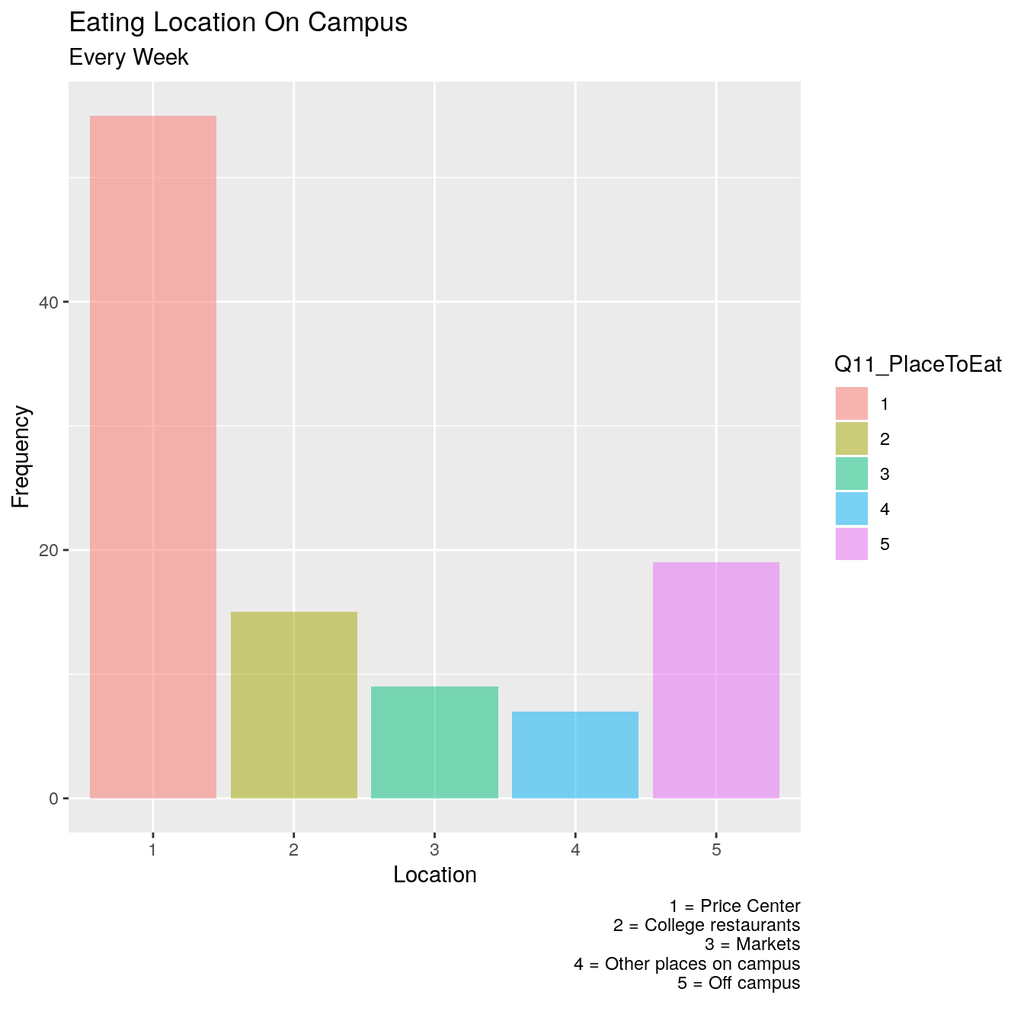

```r
result <- pivotr(
  project_data,
  cvars = "Q11_PlaceToEat",
  normalize = "total",
  nr = Inf
)
summary(result, perc = TRUE, dec = 2)
```

```
Pivot table
Data        : project_data
Categorical : Q11_PlaceToEat
Normalize by: total

 Q11_PlaceToEat   n_obs
              1  52.38%
              2  14.29%
              3   8.57%
              4   6.67%
              5  18.10%
          Total 100.00%
```

```r
# dtab(result, perc = TRUE, dec = 2) %>% render()
```

> From the distribution and pivot table above, we reach the conclusion that more than half of students (52.38%) choose Price Center for meals on weekdays, and the number is much larger than other options. Off-campus is the second popular choice, which takes 18.1% of all respondents.

```r
result <- pivotr(
  project_data,
  cvars = "Q11_Other_Text",
  data_filter = "Q11_Other_Text != ''",
  nr = Inf
)
summary(result)
```

```
Pivot table
Data        : project_data
Filter      : Q11_Other_Text != ''
Categorical : Q11_Other_Text

                                         Q11_Other_Text n_obs
                                         cook by myself     1
                                                 I cook     1
                                        I usually cook.     1
                                     old student center     1
 Order takeouts and pick up at Gilman parking structure     1
                                                  Total     5
```

```r
# dtab(result) %>% render()
```

> For people choosing other places on campus, they either cook, go to old student center, or order takeouts.

```r
## recode variable
project_data <- mutate(project_data, Q11_PC = car::Recode(Q11_PlaceToEat, "lo:2 = 'PC'; else = 'Not PC'"))
```

```r
## change variable type
project_data <- mutate_ext(project_data, .vars = vars(Q14_DurationWaitTime), .funs = as_numeric, .ext = "_Num")
```

```r
result <- compare_means(
  project_data,
  var1 = "Q11_PC",
  var2 = "Q14_DurationWaitTime_Num",
  alternative = "greater"
)
summary(result, show = FALSE)
```

```
Pairwise mean comparisons (t-test)
Data      : project_data
Variables : Q11_PC, Q14_DurationWaitTime_Num
Samples   : independent
Confidence: 0.95
Adjustment: None

 Q11_PC  mean  n n_missing    sd    se    me
 Not PC 1.829 35         0 0.785 0.133 0.270
     PC 1.971 70         0 0.834 0.100 0.199

 Null hyp.     Alt. hyp.     diff   p.value
 Not PC = PC   Not PC > PC   -0.143 0.804

Signif. codes:  0 '***' 0.001 '**' 0.01 '*' 0.05 '.' 0.1 ' ' 1
```

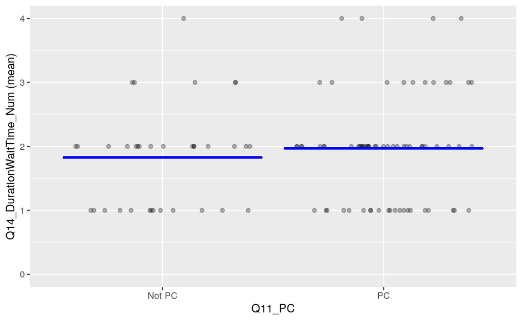

```r
plot(result, plots = "scatter", custom = FALSE)
```

> We split the data into two groups: those who choose PC and those not. And we want to know if people go to PC tend to wait for less time, by conducting hypothesis testing to compare group means of the longest waiting time. We encode the option “Less than 10 minutes” as 1, and the number increases by 1 as waiting time indicated by options increases.

> From the above results, the p value is greater than 0.05, so we fail to reject the null hypothesis, which indicates that the reason people choose PC is not shorter waiting time, maybe of other reasons.

### Part C. Order Delivery Food

> How many people have ever ordered food delivery?

```r
visualize(
  project_data,
  xvar = "Q17_Delivery",
  type = "dist",
  fill = "Q17_Delivery",
  labs = list(
    title = "The Number of People Who Have Ever Ordered Delivery Food",
    caption = "0 = no \n1 = yes",
    x = "Ordered or not",
    y = "Number of people"
  ),
  custom = FALSE
)
```

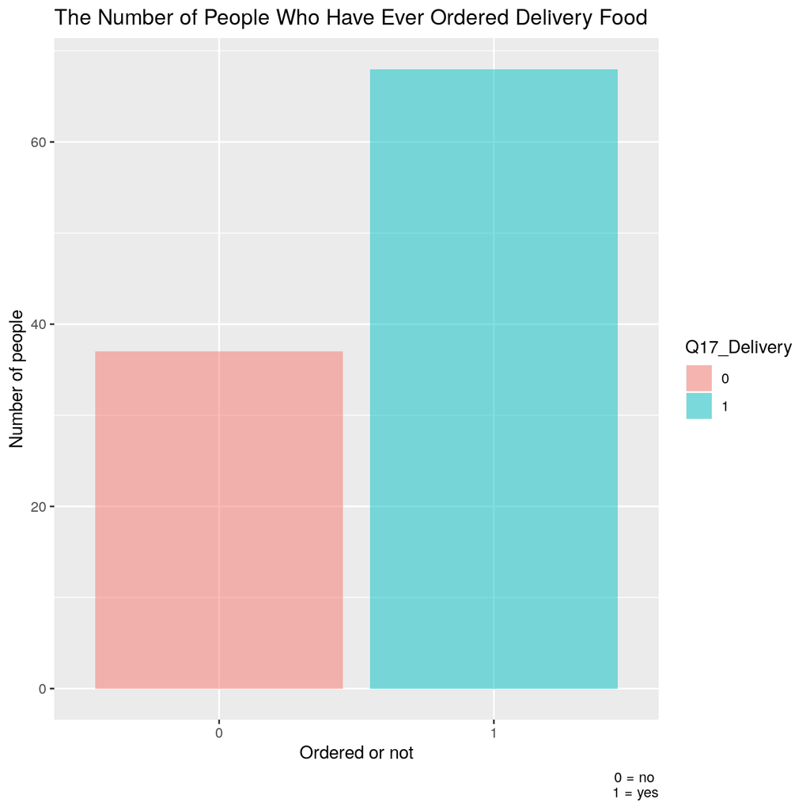

```r
result <- pivotr(
  project_data,
  cvars = "Q17_Delivery",
  normalize = "total",
  nr = Inf
)
summary(result, perc = TRUE)
```

```
Pivot table
Data        : project_data
Categorical : Q17_Delivery
Normalize by: total

 Q17_Delivery    n_obs
            0  35.238%
            1  64.762%
        Total 100.000%
```

```r
# dtab(result, perc = TRUE) %>% render()
```

> Based on the graph below, 64.76% of participants have ordered delivery food, which indicates that delivery food has become a familiar life-style of most people. In our 105 participants base, 68 of them have ordered delivery food at least once. Then, we conducted deeper analysis on their experience of delivery food.

> Consuming behavior analysis of those who order delivery food 1.Frequency

```r
visualize(
  project_data,
  xvar = "Q18_DeliveryFrequency",
  type = "dist",
  fill = "Q18_DeliveryFrequency",
  labs = list(
    title = "Frequency of Ordering Delivery Food",
    caption = "1 = almost everyday\n2 = 2-3 times a week\n3 = once every two weeks\n4 = once a month",
    x = "Times of Ordering Delivery Food",
    y = "Number of people"
  ),
  custom = FALSE
)
```

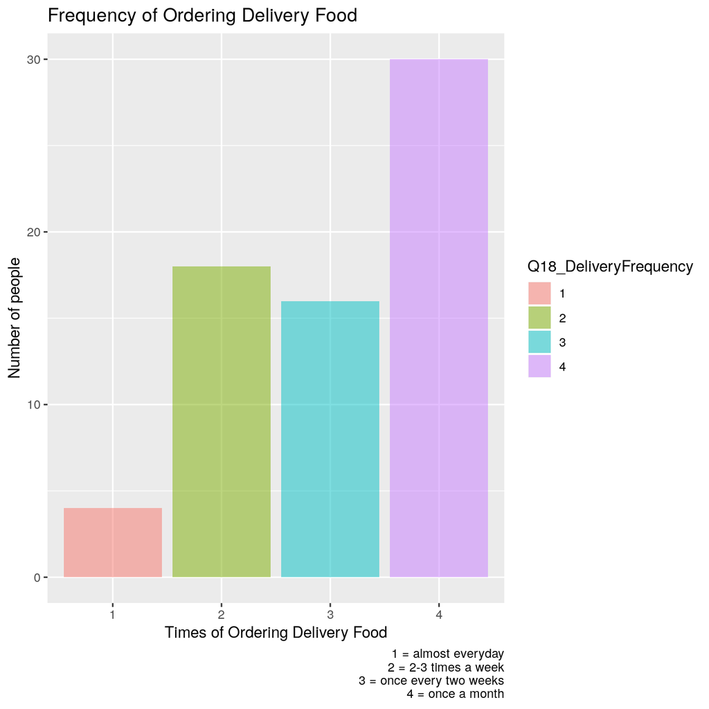

```r
result <- pivotr(
  project_data,
  cvars = "Q18_DeliveryFrequency",
  normalize = "total",
  data_filter = "Q18_DeliveryFrequency != 'NA'",
  nr = Inf
)
summary(result, perc = TRUE)
```

```
Pivot table
Data        : project_data
Filter      : Q18_DeliveryFrequency != 'NA'
Categorical : Q18_DeliveryFrequency
Normalize by: total

 Q18_DeliveryFrequency    n_obs
                     1   5.882%
                     2  26.471%
                     3  23.529%
                     4  44.118%
                 Total 100.000%
```

```r
# dtab(result, perc = TRUE) %>% render()
```

> In the 68 participants who have once ordered delivery food, 67.64% of them order delivery food occasionally(which is defined that, people order delivery food less than every half a month). Only 5.88% of participants are highly rely on delivery food, and 26.47% of participants order 2-3 times a week.

> We can estimate the demand of each day. Assume that we 100 people and each person have two meals during school day, 5.882 *((1+2)/2)/10 + 26.471* ((4+6)/2)/10 + 23.529 * 1/20 + 44.118 * 1/40 = 16.40. That is to say, in the whole population of students who buy food during school days, 16.40% of them would order delivery food, which is a huge demand.
> 2. Satisfaction level

```r
result <- explore(
  project_data,
  vars = "Q19_DeliveryScore",
  fun = c("n_obs", "mean", "min", "max", "sd"),
  data_filter = "Q18_DeliveryFrequency != 'NA'",
  nr = Inf
)
summary(result)
```

```
Explore
Data        : project_data
Filter      : Q18_DeliveryFrequency != 'NA'
Functions   : n_obs, mean, min, max, sd
Top         : Function

          variable n_obs   mean min max     sd
 Q19_DeliveryScore    68 68.985  20  95 15.813
```

```r
# dtab(result) %>% render()
```

```r
result <- explore(
  project_data,
  vars = "Q19_DeliveryScore",
  byvar = "Q18_DeliveryFrequency",
  fun = c("n_obs", "mean", "min", "max", "sd"),
  data_filter = "Q18_DeliveryFrequency != 'NA'",
  nr = Inf
)
summary(result)
```

```
Explore
Data        : project_data
Filter      : Q18_DeliveryFrequency != 'NA'
Grouped by  : Q18_DeliveryFrequency
Functions   : n_obs, mean, min, max, sd
Top         : Function

 Q18_DeliveryFrequency          variable n_obs   mean min max     sd
                     1 Q19_DeliveryScore     4 73.000  64  86  9.274
                     2 Q19_DeliveryScore    18 70.667  49  95 11.241
                     3 Q19_DeliveryScore    16 76.438  65  90  7.348
                     4 Q19_DeliveryScore    30 63.467  20  95 20.017
```

```r
# dtab(result) %>% render()
```

> In the above table, the number in delivery frequency stands for : 1: almost everyday; 2: 2-3 times a week; 3: once every two weeks; 4: once a month.

```r
visualize(
  project_data,
  xvar = "Q18_DeliveryFrequency",
  yvar = "Q19_DeliveryScore",
  type = "scatter",
  nrobs = -1,
  labs = list(
    title = "Frequency of Ordering Delivery Food",
    caption = "1 = almost everyday\n2 = 2-3 times a week\n3 = once every two weeks\n4 = once a month",
    x = "Times of Ordering Delivery Food",
    y = "Number of people"
  ),
  data_filter = "Q18_DeliveryFrequency != 'NA'",
  custom = FALSE
)
```

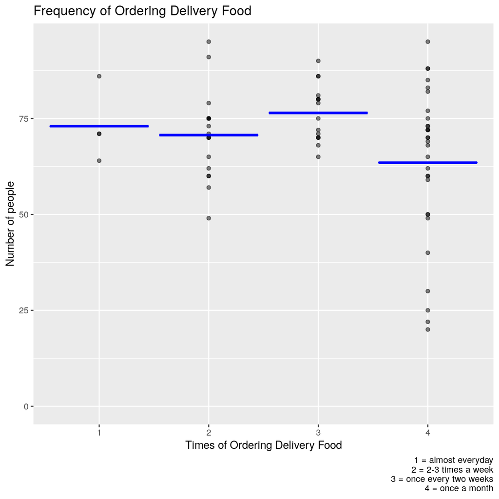

```r
## create new variable(s)
project_data <- mutate(project_data, Satisfy = ifelse(Q19_DeliveryScore >= 60,1,0))
```

```r
result <- pivotr(
  project_data,
  cvars = "Satisfy",
  normalize = "total",
  data_filter = "Satisfy != 'NA'",
  nr = Inf
)
summary(result, perc = TRUE)
```

```
Pivot table
Data        : project_data
Filter      : Satisfy != 'NA'
Categorical : Satisfy
Normalize by: total

 Satisfy    n_obs
       0  16.176%
       1  83.824%
   Total 100.000%
```

```r
# dtab(result, perc = TRUE) %>% render()
```

> We assume that if the score is equal to or bigger than 60, than he is generally satisfied with delivery food service. We added another column to define whether a person is satisfiesd or not, which will be used in later parts.
> 3. Unsatisfied Features

```r
## create new variable(s)
project_data <- mutate(project_data, Q20_uu1 = ifelse(Q20_UnsatisfiedFeature == "1" | Q20_UnsatisfiedFeature == "1,2" | Q20_UnsatisfiedFeature =="1,2,3" | Q20_UnsatisfiedFeature =="1,2,3,6" | Q20_UnsatisfiedFeature=="1,2,6" | Q20_UnsatisfiedFeature=="1,3" | Q20_UnsatisfiedFeature=="1,3,6" | Q20_UnsatisfiedFeature == "1,6",1,0))
## create new variable(s)
project_data <- mutate(project_data, Q20_uu2 = ifelse(Q20_UnsatisfiedFeature == "2" | Q20_UnsatisfiedFeature == "1,2" | Q20_UnsatisfiedFeature =="1,2,3" | Q20_UnsatisfiedFeature =="1,2,3,6" | Q20_UnsatisfiedFeature=="1,2,6" | Q20_UnsatisfiedFeature=="2,3" | Q20_UnsatisfiedFeature=="2,3,6" | Q20_UnsatisfiedFeature == "2,6",1,0))
## create new variable(s)
project_data <- mutate(project_data, Q20_uu3 = ifelse(Q20_UnsatisfiedFeature == "3" | Q20_UnsatisfiedFeature == "1,3" | Q20_UnsatisfiedFeature =="1,2,3" | Q20_UnsatisfiedFeature =="1,2,3,6" | Q20_UnsatisfiedFeature=="1,3,6" | Q20_UnsatisfiedFeature=="2,3" | Q20_UnsatisfiedFeature=="2,3,6",1,0))
## create new variable(s)
project_data <- mutate(project_data, Q20_uu6 = ifelse(Q20_UnsatisfiedFeature == "1,6" | Q20_UnsatisfiedFeature =="1,2,6" | Q20_UnsatisfiedFeature =="1,2,3,6" | Q20_UnsatisfiedFeature=="1,3,6" | Q20_UnsatisfiedFeature=="2,6" | Q20_UnsatisfiedFeature=="2,3,6",1,0))
```

```r
result <- explore(
  project_data,
  vars = c("Q20_uu1", "Q20_uu2", "Q20_uu3", "Q20_uu6"),
  fun = c("n_obs", "mean"),
  nr = Inf
)
summary(result)
```

```
Explore
Data        : project_data
Functions   : n_obs, mean
Top         : Function

 variable n_obs  mean
  Q20_uu1   105 0.706
  Q20_uu2   105 0.706
  Q20_uu3   105 0.265
  Q20_uu6   105 0.206
```

```r
# dtab(result) %>% render()
```

> To provide better service for delivery food, we designed a question about what features make you unsatisfied with delivery food. Q20-uu1 stands for “Long wait”, Q20-uu2 stands for “Expensive Delivery Fee”, Q20-uu3 stands for “Low quality food”, Q20-uu4 stands for “Bad services”. The result shows that the most important two features are: Long wait and Expensive delivery fee. By comparision, low quality and bad service are not most important items.

> Regression: satisfaction score vs. unsatisfied factor

```r
result <- regress(
  project_data,
  rvar = "Q19_DeliveryScore",
  evar = c("Q20_uu1", "Q20_uu2", "Q20_uu3", "Q20_uu6")
)
summary(result, sum_check = "rmse")
```

```
Linear regression (OLS)
Data     : project_data
Response variable    : Q19_DeliveryScore
Explanatory variables: Q20_uu1, Q20_uu2, Q20_uu3, Q20_uu6
Null hyp.: the effect of x on Q19_DeliveryScore is zero
Alt. hyp.: the effect of x on Q19_DeliveryScore is not zero

             coefficient std.error t.value p.value
 (Intercept)      68.333     5.674  12.044  < .001 ***
 Q20_uu1          -4.486     4.535  -0.989   0.326
 Q20_uu2           5.225     4.479   1.167   0.248
 Q20_uu3           0.296     4.782   0.062   0.951
 Q20_uu6           0.254     5.240   0.048   0.962

Signif. codes:  0 '***' 0.001 '**' 0.01 '*' 0.05 '.' 0.1 ' ' 1

R-squared: 0.051,  Adjusted R-squared: -0.01
F-statistic: 0.838 df(4,63), p.value 0.506
Nr obs: 68

Prediction error (RMSE):  15.295
Residual st.dev   (RSD):  15.89
```

> We wonder that whether people’s satisfaction score is depend on the reason why they do not like delivery food. Therefore, we build a regression model. Same as below, Q20-uu1 stands for “Long wait”, Q20-uu2 stands for “Expensive Delivery Fee”, Q20-uu3 stands for “Low quality food”, Q20-uu4 stands for “Bad services”.

> The model has a very low R-square and >0.1 p-value, which indicates that the four reasons do not have a significant effect on the satisfation score. It is revealed that, the satisfaction score cannot be predicted only by this four reasons. Perhaps we need to add some positive reasons into the model, or it is also possible that, people give the score only based on the most important reason that they care about.

> New choice: Nowadyas, there is a new type of delivery service. Customers should place an order for their deliveries one noght in advance. On next morning, the food will be delivered to the designed place on time without waiting. After a brief investigation, we found that a several of Chinese restaurants have already started this kind of service. To test whether this will a warmly-welcomed service, we asked the opinion that whether people would like to try this service.

```r
result <- explore(
  project_data,
  vars = c("Q22_NewChoice_y", "Q23_NewChoice_n"),
  fun = c("n_obs", "mean"),
  nr = Inf
)
summary(result)
```

```
Explore
Data        : project_data
Functions   : n_obs, mean
Top         : Function

        variable n_obs  mean
 Q22_NewChoice_y   105 0.309
 Q23_NewChoice_n   105 0.378
```

```r
# dtab(result) %>% render()
```

> In the result table, Q22_NewChoice_y is a one-hot variable for people who have once ordered delivery food. If people have interest in this service, the output is 1, vice versa. Q23_NewChoice_n is a one-hot variable for people who have never ordered delivery food. If people have interest in this service, the output is 1, vice versa.

> We can conclude from the result table that, 30.9% of people who have ordered delivery food before have interest in this new service and 37.8% of people who have never ordered delivery food before have interest in this new service. The result doesn’t have big difference.

```r
result <- explore(
  project_data,
  vars = c("Q21_DurableDeliveryPrice_y", "Q24_DurableDeliveryPrice_n"),
  fun = c("n_obs", "mean"),
  nr = Inf
)
summary(result)
```

```
Explore
Data        : project_data
Functions   : n_obs, mean
Top         : Function

                   variable n_obs  mean
 Q21_DurableDeliveryPrice_y   105 0.309
 Q24_DurableDeliveryPrice_n   105 0.486
```

```r
# dtab(result) %>% render()
```

> Availabe price range for delivery food for people who have ordered delivery food before

```r
visualize(
  project_data,
  xvar = "Q21_DurableDeliveryPrice_y",
  type = "dist",
  fill = "Q21_DurableDeliveryPrice_y",
  labs = list(
    title = "Preferred Price Range for Delivery Food",
    subtitle = "(for people who have ordered delivery food before)",
    caption = "1: < $15\n2: $16 - $20\n3: $20 - $30\n4: $30 - $40\n5: > $40",
    x = "Price Range",
    y = "Count"
  ),
  data_filter = "Satisfy != 'NA'",
  custom = FALSE
)
```

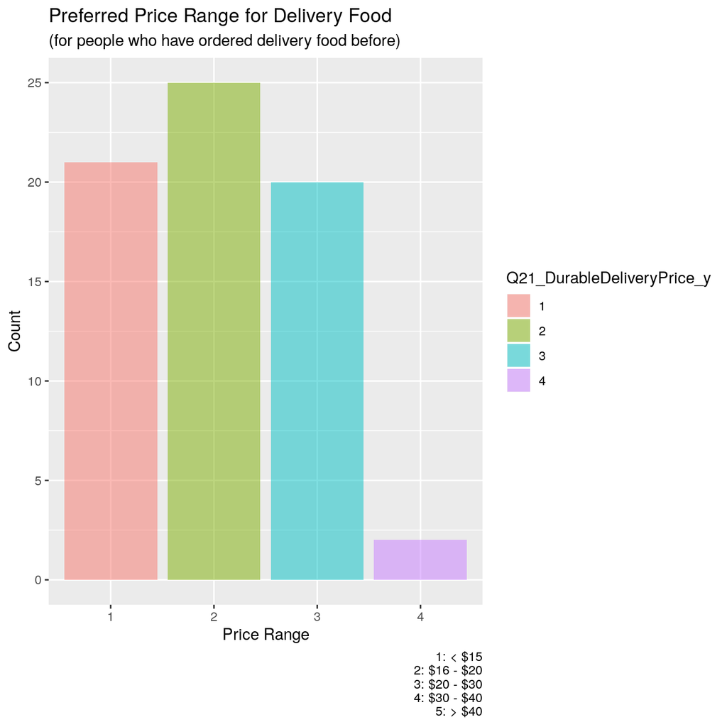

> for people who have never ordered delivery food before

```r
visualize(
  project_data,
  xvar = "Q24_DurableDeliveryPrice_n",
  type = "dist",
  fill = "Q24_DurableDeliveryPrice_n",
  labs = list(
    title = "Preferred Price Range for Delivery Food",
    subtitle = "(for people who have never ordered delivery food before)",
    caption = "1: < $15\n2: $16 - $20\n3: $20 - $30\n4: $30 - $40\n5: > $40",
    x = "Price Range",
    y = "Count"
  ),
  custom = FALSE
)
```

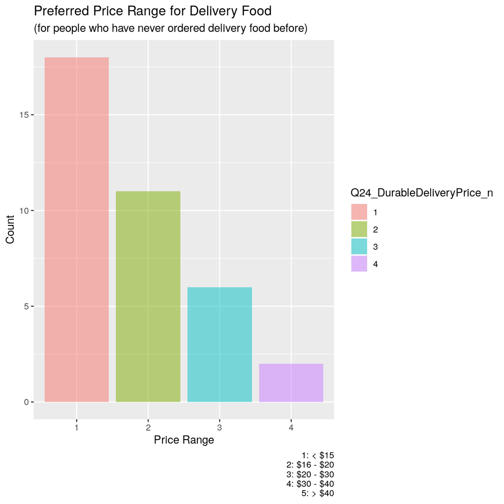

> Comparing the two plots above, for those who have ordered delivery food before, most of them prefer the $16-$20 price range, while for those who have never ordered delivery food before, most of them prefer the < $15 price range. In both of the two groups, >$40 is not an available choice.

### Part D. Other Analysis

**Public Awareness (Advertisement)**

> We also analyze the public awareness of Taste of Hunan as below:

```r
## recode variable
project_data <- mutate(project_data, Q8_KnoworNot = car::Recode(Q8_KnoworNot, "2=1; 3=0"))
```

```r
visualize(
  project_data,
  xvar = "Q8_KnoworNot",
  type = "dist",
  fill = "Q8_KnoworNot",
  labs = list(
    title = "Public Awareness of Taste of Hunan",
    caption = "0 = Unknown\n1 = Known\n",
    x = "Public Awareness",
    y = "Counts"
  ),
  custom = FALSE
)
```

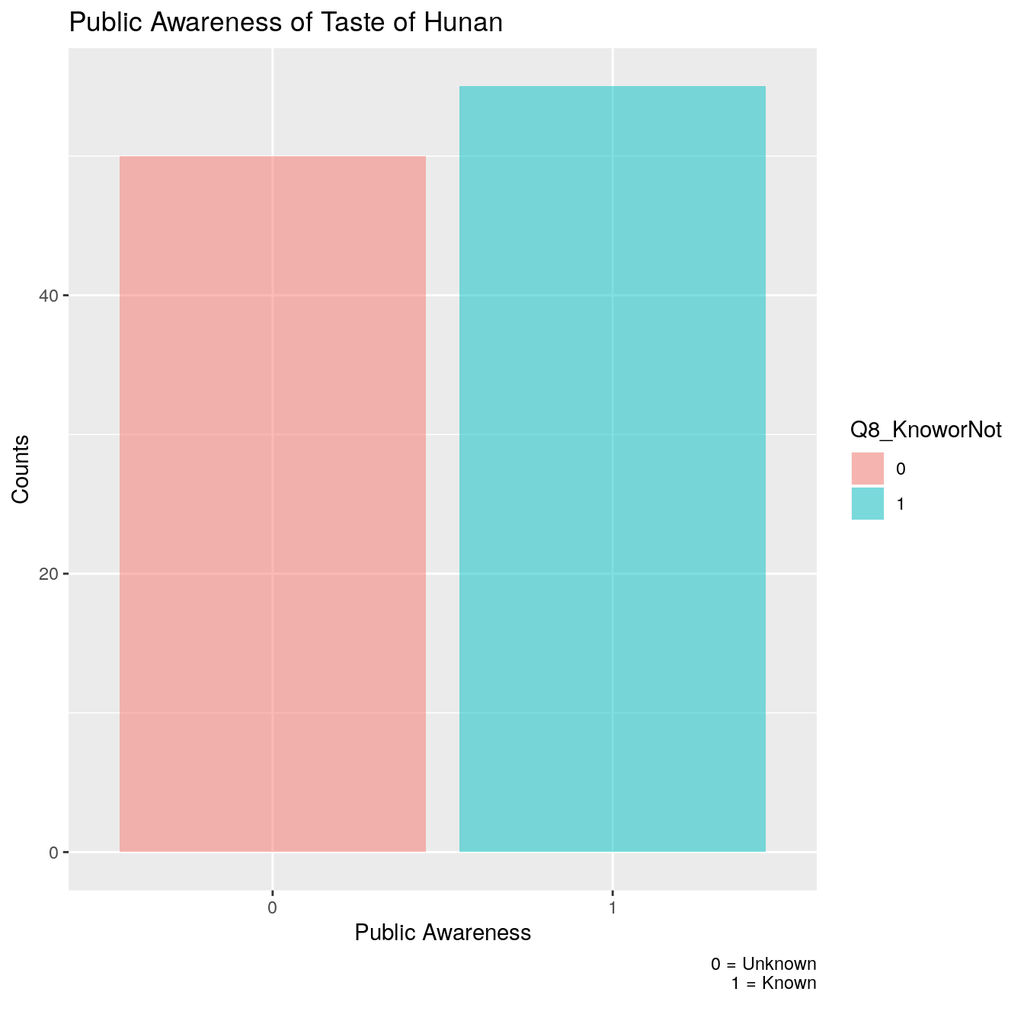

```r
result <- pivotr(
  project_data,
  cvars = "Q8_KnoworNot",
  normalize = "total",
  nr = Inf
)
summary(result, perc = TRUE, dec = 2)
```

```
Pivot table
Data        : project_data
Categorical : Q8_KnoworNot
Normalize by: total

 Q8_KnoworNot   n_obs
            0  47.62%
            1  52.38%
        Total 100.00%
```

```r
# dtab(result, perc = TRUE, dec = 2) %>% render()
```

> From the distribution above, we can find that 47.62% of the sample size do not know Taste of Hunan, which means that almost half of the sample size do not know this restaurant.

**Source**

> To figure our a good way that Tast of Hunan should use to improve its public awareness, we do the distribution of source that people have to know a new restaurant. The result is shown as below:

```r
visualize(
  project_data,
  xvar = "Q16_Source",
  type = "dist",
  fill = "Q16_Source",
  labs = list(
    title = "Sources for Knowing a New Restaurant",
    caption = "1 = Recommendation from friends and family\n2 = Leaflet\n3 = Email\n4 = Billboards\n5 = Other\n",
    x = "Sources",
    y = "Counts"
  ),
  custom = FALSE
)
```

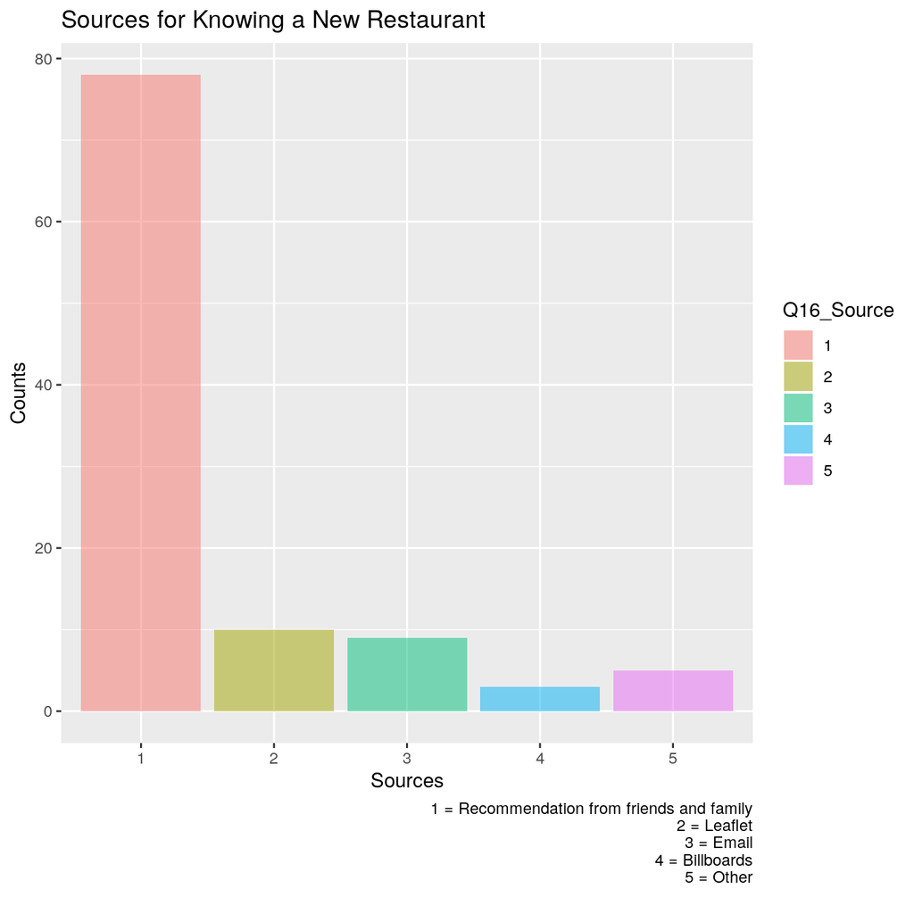

```r
result <- pivotr(
  project_data,
  cvars = "Q16_Source",
  normalize = "total",
  nr = Inf
)
summary(result, perc = TRUE, dec = 2)
```

```
Pivot table
Data        : project_data
Categorical : Q16_Source
Normalize by: total

 Q16_Source   n_obs
          1  74.29%
          2   9.52%
          3   8.57%
          4   2.86%
          5   4.76%
      Total 100.00%
```

```r
# dtab(result, perc = TRUE, dec = 2) %>% render()
```

> From the distribution above, we can find that 74.29% of our sample size know a new restaurant based on recommendation from friends and family. So, to improve its public awareness, it is a good way for Taste of Hunan to post the advertisement on the social network.

**Price**

> By doing a hypothesis test, we try to find whether the durable price that people will pay for a meal is greater than the average price that people pay for a meal on campus.

```r
## change variable type
project_data <- mutate_at(project_data, .vars = vars(Q12_PricePay, Q13_DurablePrice), .funs = as_numeric)
```

```r
result <- compare_means(
  project_data,
  var1 = "Q13_DurablePrice",
  var2 = "Q12_PricePay",
  alternative = "greater",
  comb = "1:2"
)
summary(result, show = FALSE)
```

```
Pairwise mean comparisons (t-test)
Data      : project_data
Variables : Q13_DurablePrice, Q12_PricePay
Samples   : independent
Confidence: 0.95
Adjustment: None

                   mean   n n_missing    sd    se    me
 Q13_DurablePrice 2.133 105         0 1.010 0.099 0.195
     Q12_PricePay 1.295 105         0 0.536 0.052 0.104

 Null hyp.                         Alt. hyp.                         diff  p.value
 Q13_DurablePrice = Q12_PricePay   Q13_DurablePrice > Q12_PricePay   0.838 < .001  ***

Signif. codes:  0 '***' 0.001 '**' 0.01 '*' 0.05 '.' 0.1 ' ' 1
```

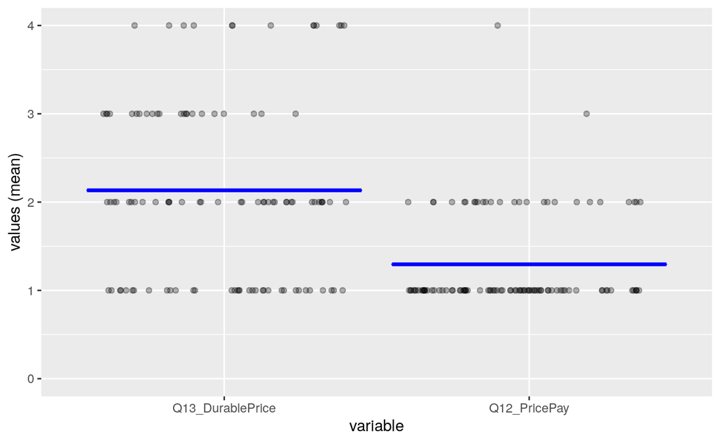

```r
plot(result, plots = "scatter", custom = FALSE)
```

> From the hypothesis test above, we can get that the p-value is less than 0.001. Since the p-value is less than 0.05 (using a 5% significant level), we can reject the null hypothesis. So, we can conclude that the durable price that people will pay for a meal is greater than the average price that people pay for a meal on campus.

> The distribution of durable price is shown as below:

```r
## change variable type
project_data <- mutate_at(project_data, .vars = vars(Q12_PricePay, Q13_DurablePrice), .funs = as_factor)
```

```r
visualize(
  project_data,
  xvar = "Q13_DurablePrice",
  type = "dist",
  fill = "Q13_DurablePrice",
  labs = list(
    title = "Durable Price Distribution",
    caption = "1 = Less than $14\n2 = $15-$20\n3 = $21-$26\n4 = More than $26\n",
    x = "Durable Price",
    y = "Counts"
  ),
  custom = FALSE
)
```

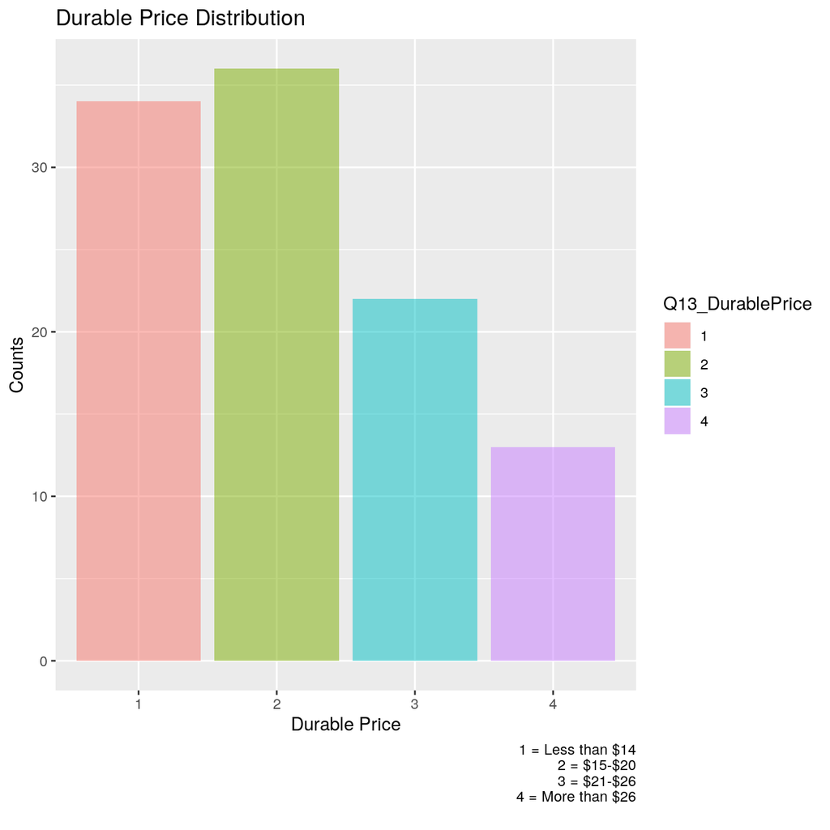

```r
result <- pivotr(
  project_data,
  cvars = "Q13_DurablePrice",
  normalize = "total",
  nr = Inf
)
summary(result, perc = TRUE, dec = 2)
```

```
Pivot table
Data        : project_data
Categorical : Q13_DurablePrice
Normalize by: total

 Q13_DurablePrice   n_obs
                1  32.38%
                2  34.29%
                3  20.95%
                4  12.38%
            Total 100.00%
```

```r
# dtab(result, perc = TRUE, dec = 2) %>% render()
```

> The distribution shows that compares to other price range, $15-$20 is the price range that more people can accpet.

> Based on the hypothese test and the distribution above, Taste of Hunan does not need to decrease its price level to the average price; however, it is also better for it not to set its price upon $20 for a meal.

**Services**

```r
result <- pivotr(
  project_data,
  cvars = "Q15_Attitude",
  normalize = "total",
  nr = Inf
)
# summary(result, perc = TRUE, dec = 2)
# dtab(result, perc = TRUE, dec = 2) %>% render()
Attitude <- result$tab
register("Attitude")
```

```r
## rename variable(s)
Attitude <- rename(Attitude, Q15 = Q15_Attitude)
## rename variable(s)
Attitude <- rename(Attitude, Attitude= n_obs)
```

```r
result <- pivotr(
  project_data,
  cvars = "Q15_Speed",
  normalize = "total",
  nr = Inf
)
# summary(result, perc = TRUE, dec = 2)
# dtab(result, perc = TRUE, dec = 2) %>% render()
Speed <- result$tab
register("Speed")
```

```r
## rename variable(s)
Speed <- rename(Speed, Q15 = Q15_Speed)
## rename variable(s)
Speed <- rename(Speed, Speed = n_obs)
```

```r
result <- pivotr(
  project_data,
  cvars = "Q15_Environment",
  normalize = "total",
  nr = Inf
)
# summary(result, perc = TRUE, dec = 2)
# dtab(result, perc = TRUE, dec = 2) %>% render()
Environment <- result$tab
register("Environment")
```

```r
## rename variable(s)
Environment <- rename(Environment, Q15 = Q15_Environment)
## rename variable(s)
Environment <- rename(Environment, Environment = n_obs)
```

```r
result <- pivotr(
  project_data,
  cvars = "Q15_Quality",
  normalize = "total",
  nr = Inf
)
# summary(result, perc = TRUE, dec = 2)
# dtab(result, perc = TRUE, dec = 2) %>% render()
Quality <- result$tab
register("Quality")
```

```r
## rename variable(s)
Quality <- rename(Quality, Q15 = Q15_Quality)
## rename variable(s)
Quality <- rename(Quality, Quality = n_obs)
```

```r
service_comb <- combine_data(
  x = Attitude,
  y = Speed,
  by = "Q15",
  add = "Speed",
  type = "left_join"
)
register("service_comb")
```

```r
service_comb <- combine_data(
  x = service_comb,
  y = Environment,
  by = "Q15",
  add = "Environment",
  type = "left_join"
)
register("service_comb")
```

```r
service_comb <- combine_data(
  x = service_comb,
  y = Quality,
  by = "Q15",
  add = "Quality",
  type = "left_join"
)
register("service_comb")
```

```r
service_comb
```

| Q15 | Attitude | Speed | Environment | Quality |
| --- | --- | --- | --- | --- |
| 1 | 0.33333333 | 0.61904762 | 0.21904762 | 0.71428571 |
| 2 | 0.44761905 | 0.33333333 | 0.43809524 | 0.24761905 |
| 3 | 0.16190476 | 0.03809524 | 0.26666667 | 0.00952381 |
| 4 | 0.05714286 | 0.00952381 | 0.07619048 | 0.02857143 |
| Total | 1.00000000 | 1.00000000 | 1.00000000 | 1.00000000 |

> The review of a dining place is decomposed into 4 aspects: attitude, speed, environment, and quality. Overall, these 4 aspects are all considered to be important when choosing what to eat, since large percentage of people choose 1 and 2 which stand for “very important” and “somewhat important”.